# ML2: Exam Preparation

Denis Baskan

14 March 2019

# Exercise: Boosting a Tree & SVM (Support-Vector-Machine)

## Load Packages

If packages are not installed, then they will be installed.

```r
required.packages =  c('gbm','e1071','ISLR','MASS')
load.packages <- function(packages){

  for (pckg in packages){
    if (!(pckg %in% installed.packages()[,"Package"])){
      install.packages(pckg)
    }

    library(pckg, character.only = TRUE)
  }
}

load.packages(required.packages)
```

# Boosted Tree Model

Let’s see how the boosted tree looks after a single iteration.

```r
set.seed (1)

#one iteration
mtcars.boost<-gbm(mpg ~ ., data=mtcars, n.trees=1,distribution="gaussian",shrinkage=0.1,bag.fraction=1)
mtcars.boost
```

```
## gbm(formula = mpg ~ ., distribution = "gaussian", data = mtcars,
##     n.trees = 1, shrinkage = 0.1, bag.fraction = 1)
## A gradient boosted model with gaussian loss function.
## 1 iterations were performed.
## There were 10 predictors of which 1 had non-zero influence.
```

```r
mean((mtcars$mpg-mean(mtcars$mpg))^2)  #mse of null model
```

```
## [1] 35.18897
```

```r
mtcars.boost$train.error               #mse of first boost
```

```
## [1] 30.8891
```

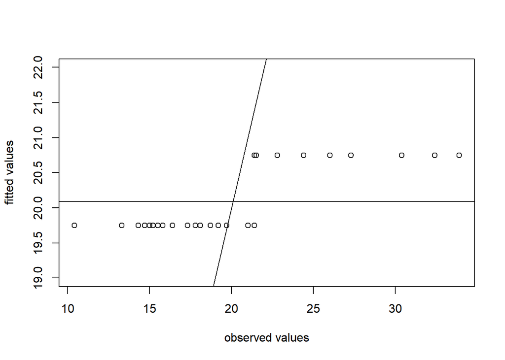

```r
#Plots
plot(mtcars$mpg,predict(mtcars.boost,n.trees=1),ylim=c(19,22),ylab="fitted values",xlab="observed values")
abline(h=mean(mtcars$mpg))
abline(c(0,1))
```

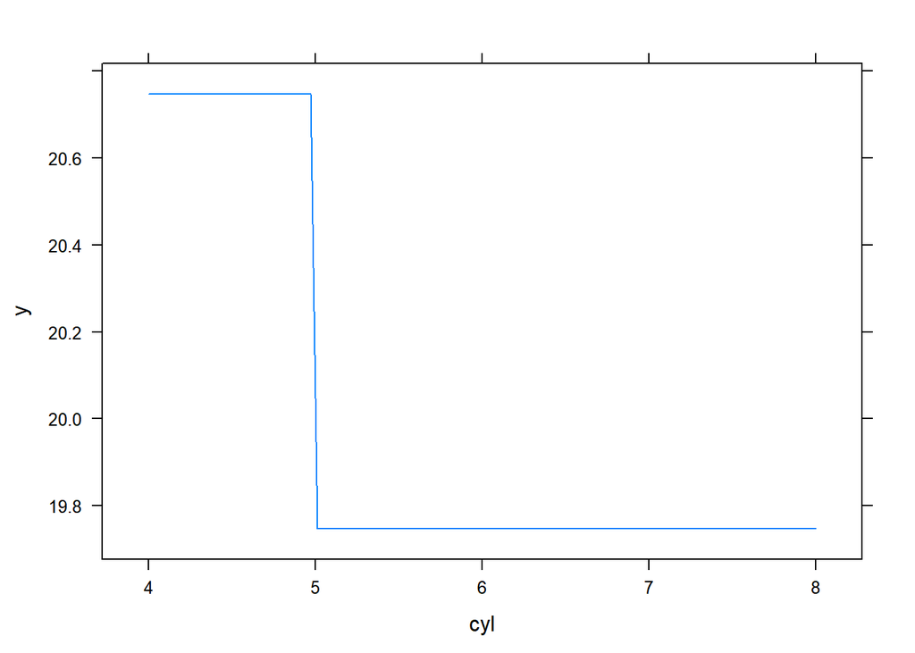

```r
plot(mtcars.boost) #effect of variable, split > 5 where the jump happens
```

Better than the Null-Model, but still not good enough for us. The horizontal line is simply the mean of outcome variable mpg. The diagonal represents the perfect fit. cyl = 5 is the value where the first split has happened.

## 2 Iterations

```r
mtcars.boost<-gbm(mpg ~ ., data=mtcars, n.trees=2,distribution="gaussian",shrinkage=0.1,bag.fraction=1)
mtcars.boost$train.error
```

```
## [1] 30.8891 27.4062
```

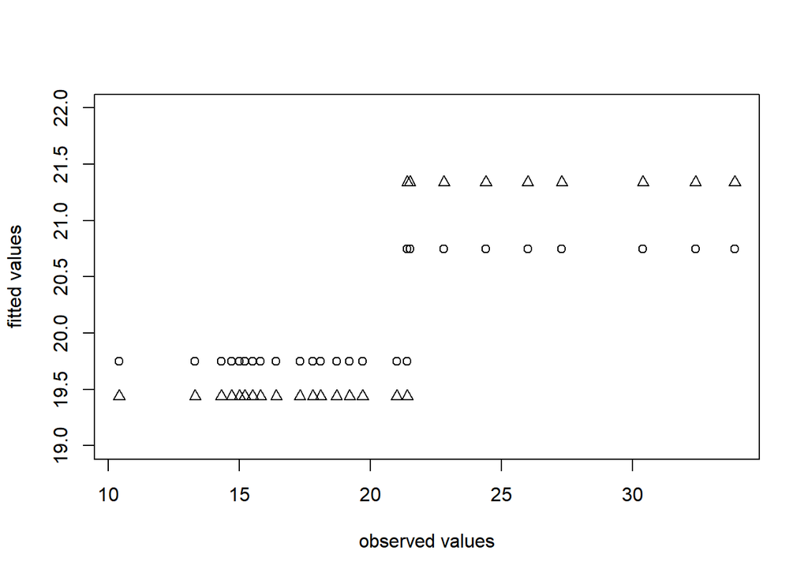

```r
plot(mtcars$mpg,predict(mtcars.boost,n.trees=1),ylim=c(19,22),ylab="fitted values",xlab="observed values")
points(mtcars$mpg,predict(mtcars.boost,n.trees=2),pch=2)
```

We can see two series of predictions in the plot. Circles and triangles each represent a tree. MSE is going down further more at least for one of the trees. Can we reduce the MSE with more iterations?

## 3 Iterations

```r
mtcars.boost<-gbm(mpg ~ ., data=mtcars, n.trees=3,distribution="gaussian",shrinkage=0.1,bag.fraction=1)
mtcars.boost$train.error
```

```
## [1] 30.88910 27.40620 24.51204
```

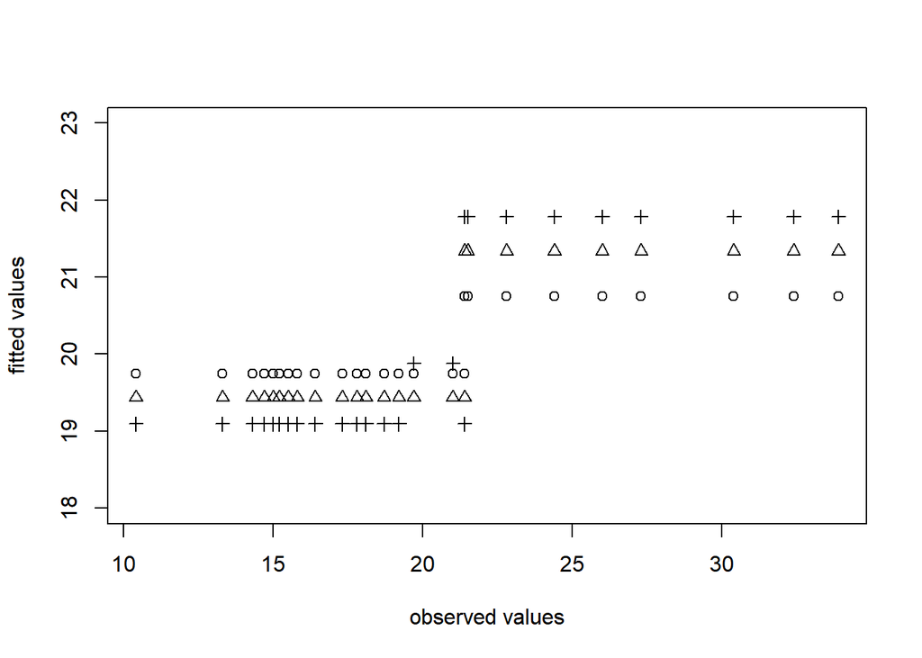

```r
plot(mtcars$mpg,predict(mtcars.boost,n.trees=1),ylim=c(18,23),ylab="fitted values",xlab="observed values")
points(mtcars$mpg,predict(mtcars.boost,n.trees=2),pch=2)
points(mtcars$mpg,predict(mtcars.boost,n.trees=3),pch=3)
```

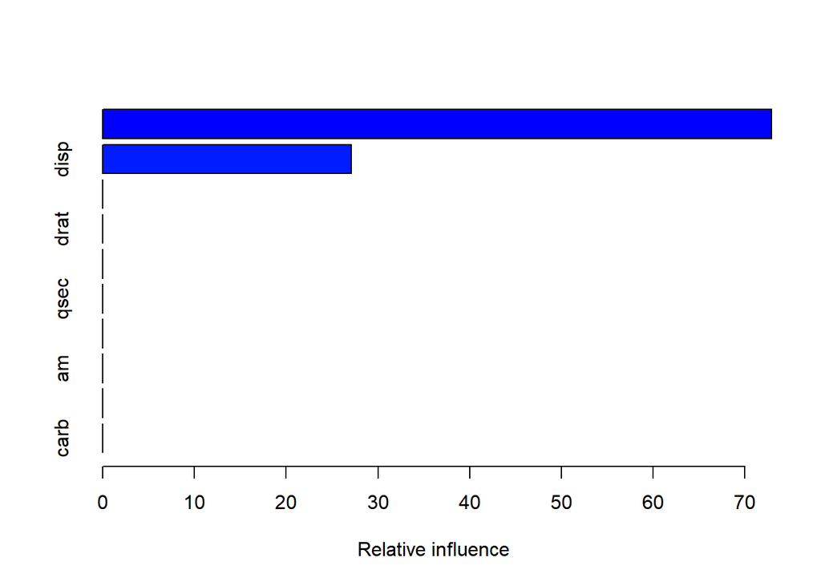

```
##       var  rel.inf
## cyl   cyl 72.89335
## disp disp 27.10665
## hp     hp  0.00000
## drat drat  0.00000
## wt     wt  0.00000
## qsec qsec  0.00000
## vs     vs  0.00000
## am     am  0.00000
## gear gear  0.00000
## carb carb  0.00000
```

```r
summary(mtcars.boost) #relative influce of each variable
```

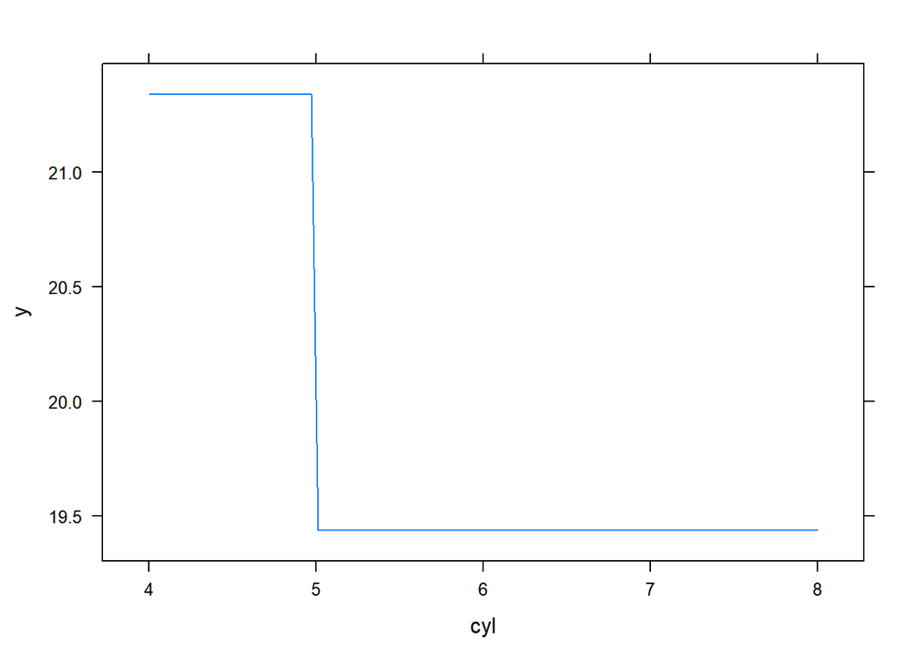

```r
plot(mtcars.boost,i.var="cyl")
```

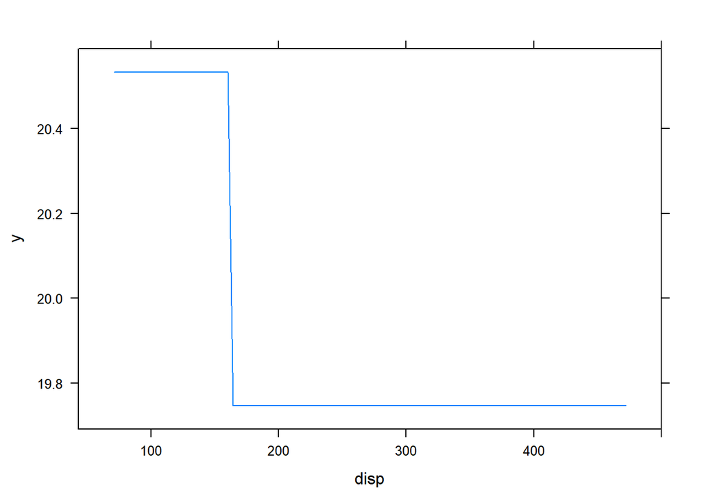

```r
plot(mtcars.boost,i.var="disp")
```

MSE is again lower with another iteration. Variables cyl and disp are by far the most important variables. For disp ~ 160 the tree has split again.

## 4 iterations

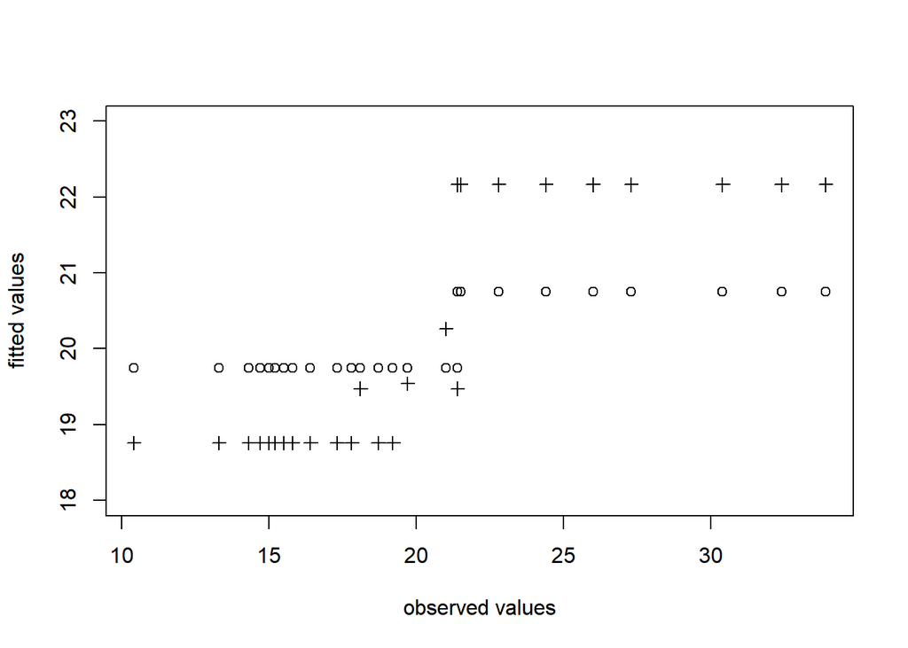

```r
mtcars.boost<-gbm(mpg ~ ., data=mtcars, n.trees=10,distribution="gaussian",shrinkage=0.1,bag.fraction=1)
plot(mtcars$mpg,predict(mtcars.boost,n.trees=1),ylim=c(18,23),ylab="fitted values",xlab="observed values")
points(mtcars$mpg,predict(mtcars.boost,n.trees=4),pch=3)
```

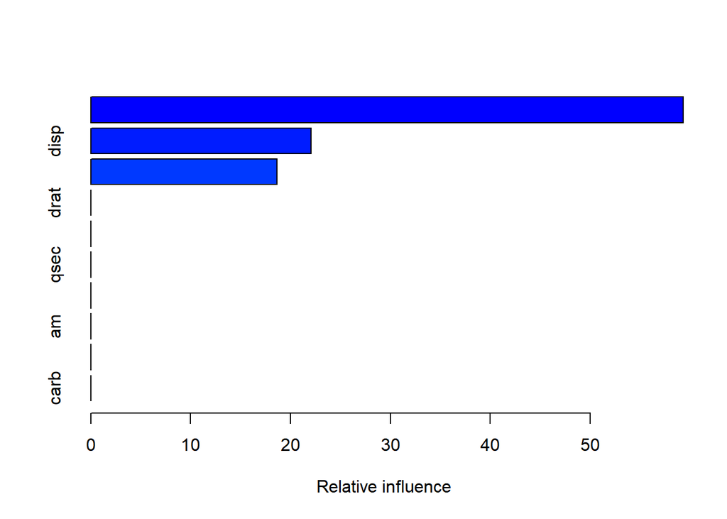

```
##       var  rel.inf
## cyl   cyl 59.32233
## disp disp 22.06003
## hp     hp 18.61765
## drat drat  0.00000
## wt     wt  0.00000
## qsec qsec  0.00000
## vs     vs  0.00000
## am     am  0.00000
## gear gear  0.00000
## carb carb  0.00000
```

```r
summary(mtcars.boost, n.trees=4)
```

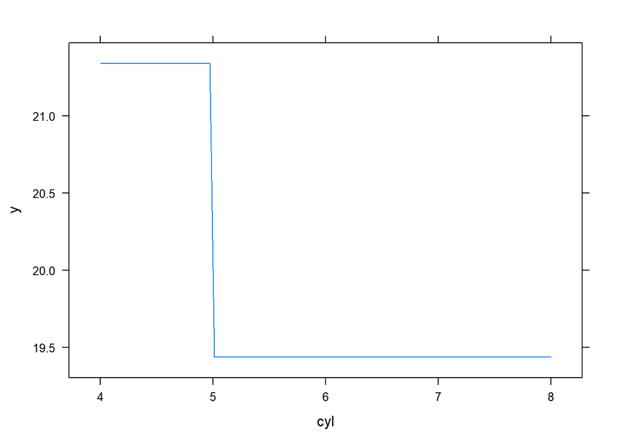

```r
plot(mtcars.boost,i.var="cyl",n.trees=4)
```

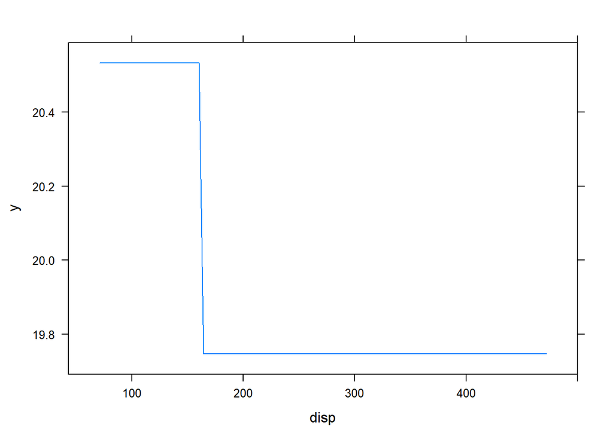

```r
plot(mtcars.boost,i.var="disp",n.trees=4)
```

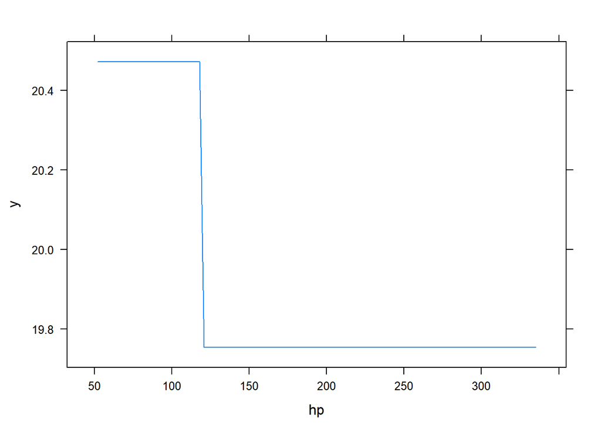

```r
plot(mtcars.boost,i.var="hp",n.trees=4)
```

The 3rd split was at a value of ~125 for the variable hp. Hence the importance of the variables cyl and disp has been declined.

## 5 iterations

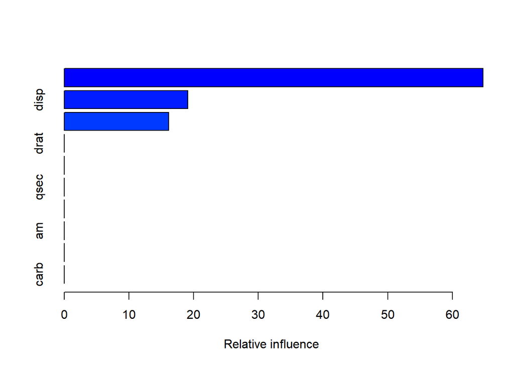

```
##       var  rel.inf
## cyl   cyl 64.73876
## disp disp 19.12263
## hp     hp 16.13862
## drat drat  0.00000
## wt     wt  0.00000
## qsec qsec  0.00000
## vs     vs  0.00000
## am     am  0.00000
## gear gear  0.00000
## carb carb  0.00000
```

```r
summary(mtcars.boost, n.trees=5)
```

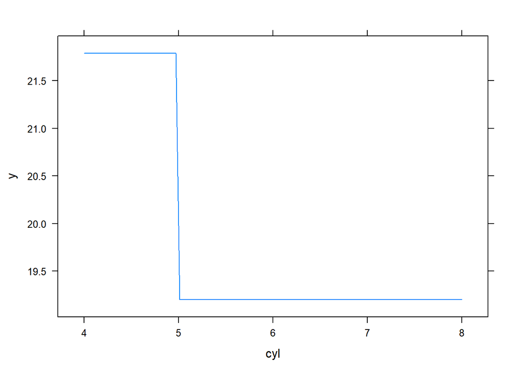

```r
plot(mtcars.boost,i.var="cyl",n.trees=5)
```

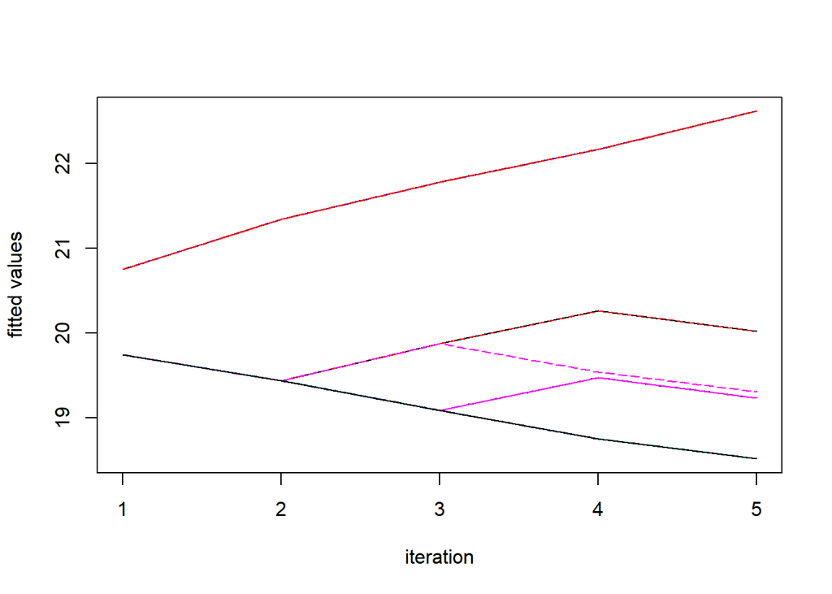

```r
matplot(t(predict(mtcars.boost,n.trees=1:5)),type="l",ylab="fitted values",xlab="iteration")
```

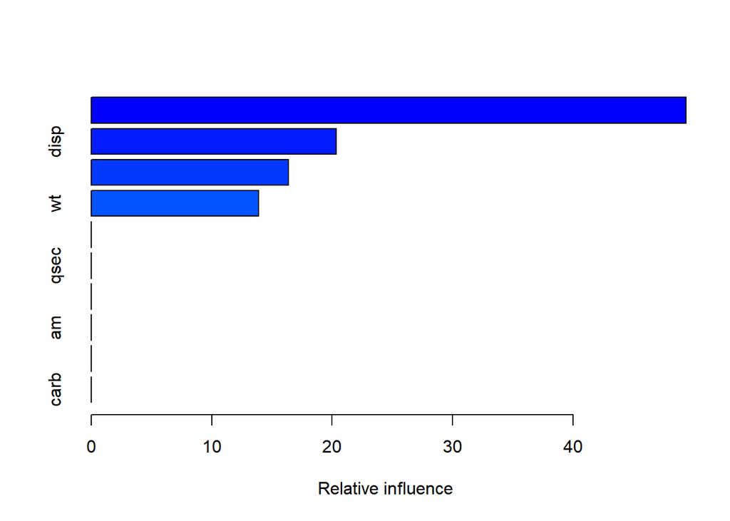

```
##       var  rel.inf
## cyl   cyl 49.38949
## disp disp 20.33954
## hp     hp 16.38800
## wt     wt 13.88297
## drat drat  0.00000
## qsec qsec  0.00000
## vs     vs  0.00000
## am     am  0.00000
## gear gear  0.00000
## carb carb  0.00000
```

```r
summary(mtcars.boost, n.trees=10)
```

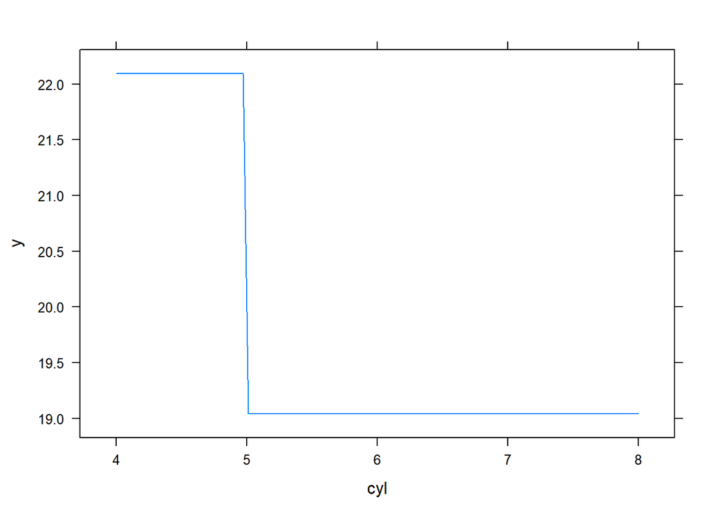

```r
plot(mtcars.boost,i.var="cyl")
```

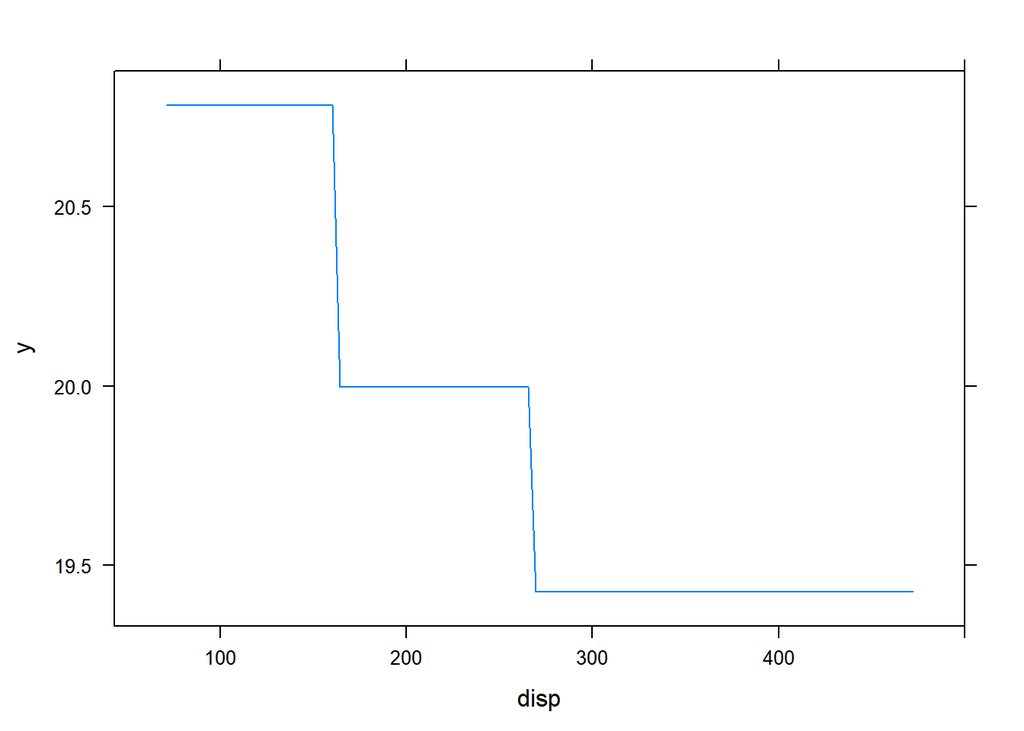

```r
plot(mtcars.boost,i.var="disp")
```

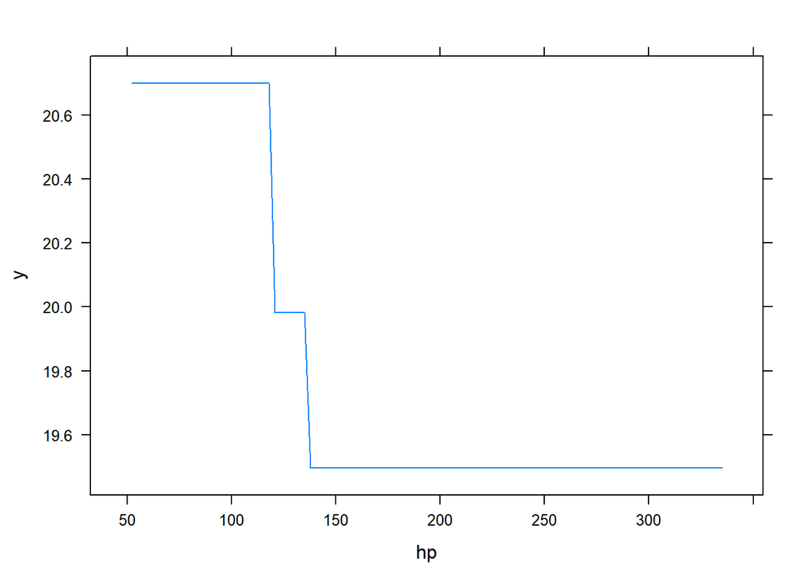

```r
plot(mtcars.boost,i.var="hp")
```

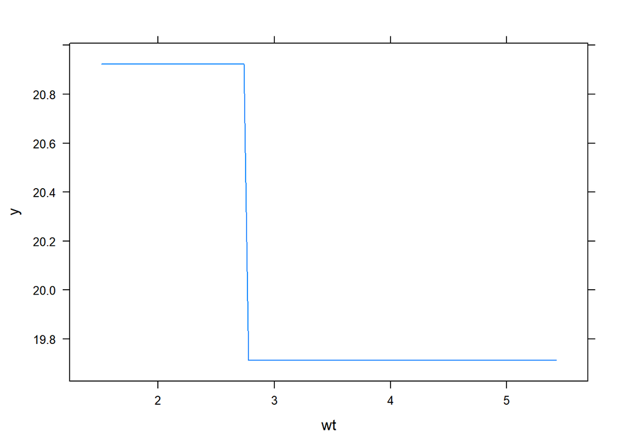

```r
plot(mtcars.boost,i.var="wt")
```

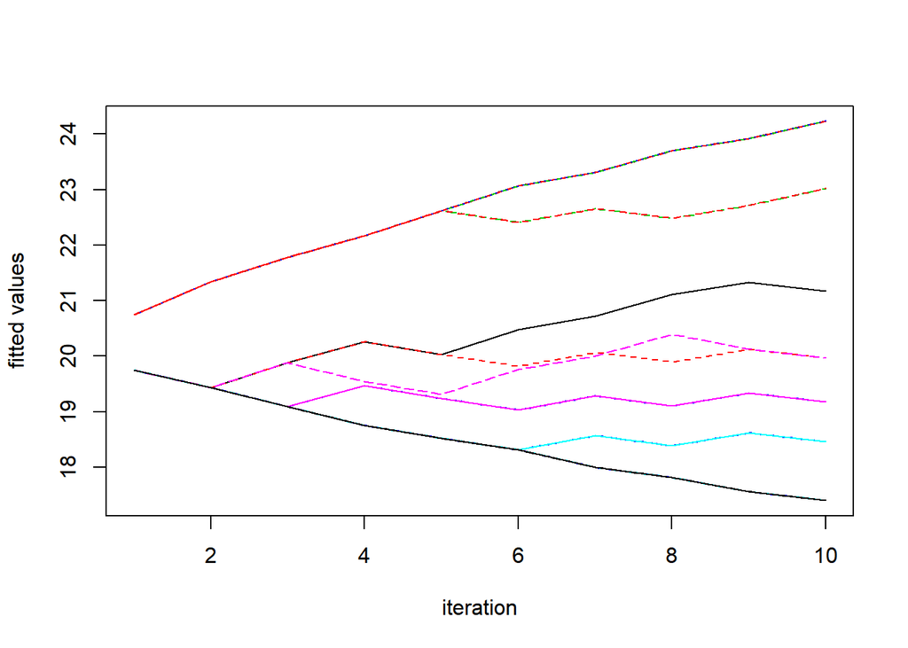

```r
matplot(t(predict(mtcars.boost,n.trees=1:10)),type="l",ylab="fitted values",xlab="iteration")
```

## 90 iterations

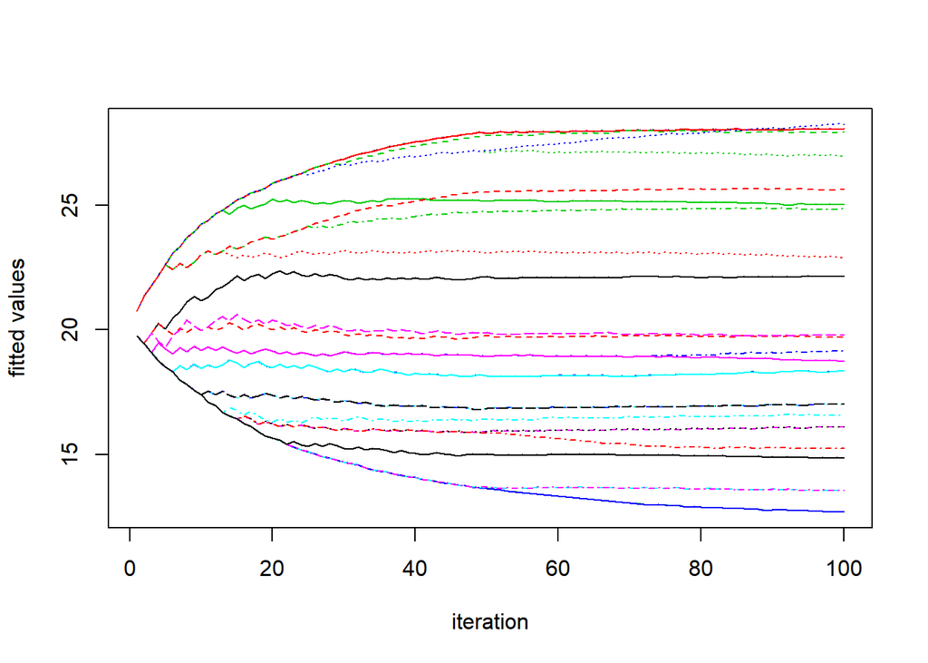

```r
mtcars.boost<-gbm.more(mtcars.boost,n.new.trees = 90)
matplot(t(predict(mtcars.boost,n.trees=1:100)),type="l",ylab="fitted values",xlab="iteration")
```

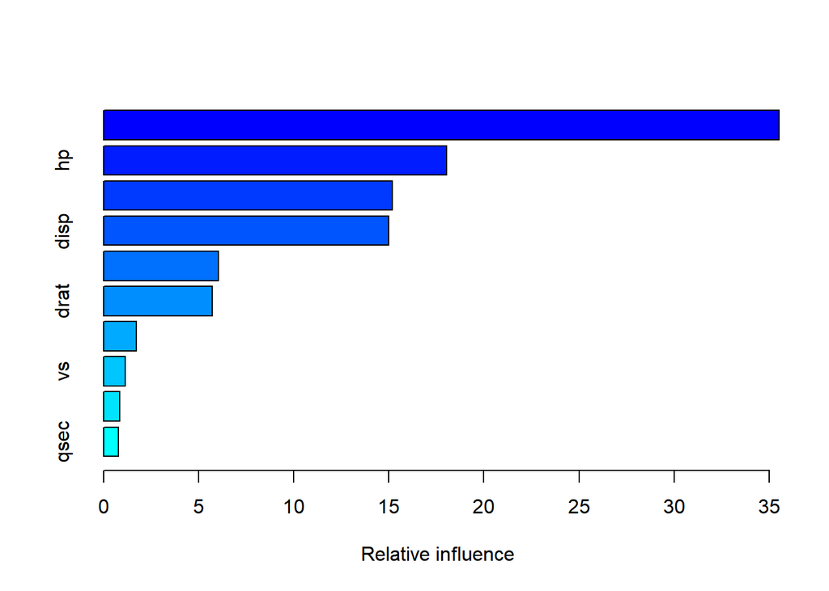

```
##       var    rel.inf
## cyl   cyl 35.5158550
## hp     hp 18.0381619
## wt     wt 15.1975678
## disp disp 14.9754092
## carb carb  6.0346971
## drat drat  5.7064964
## am     am  1.7297626
## vs     vs  1.1550008
## gear gear  0.8605528
## qsec qsec  0.7864963
```

```r
summary(mtcars.boost)
```

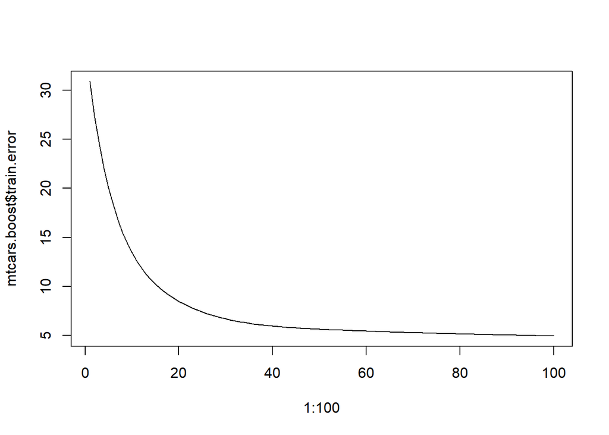

```r
plot(1:100,mtcars.boost$train.error,type="l")
```

#900 iterations

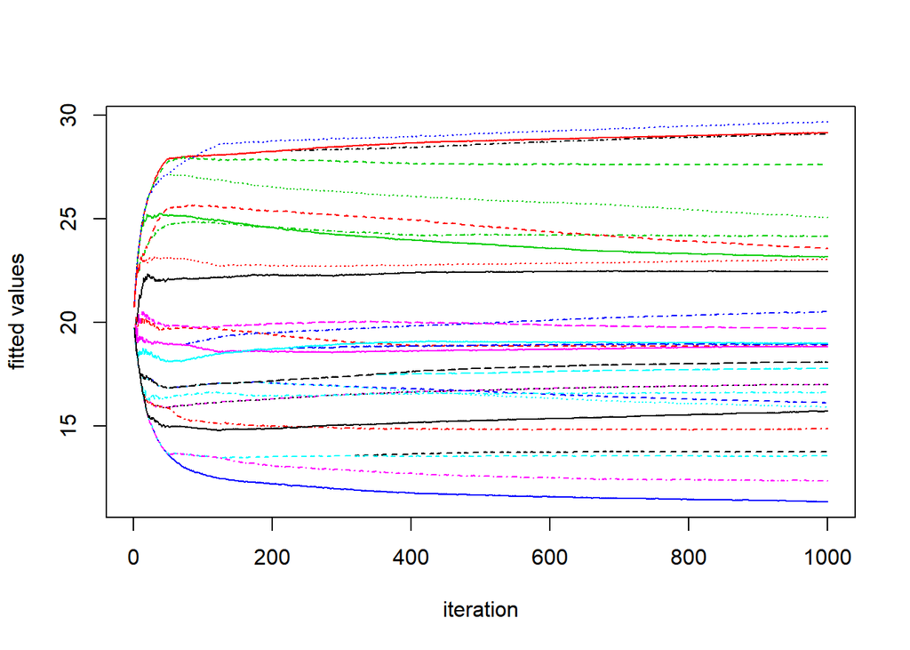

```r
mtcars.boost<-gbm.more(mtcars.boost,n.new.trees = 900)
matplot(t(predict(mtcars.boost,n.trees=1:1000)),type="l",ylab="fitted values",xlab="iteration")
```

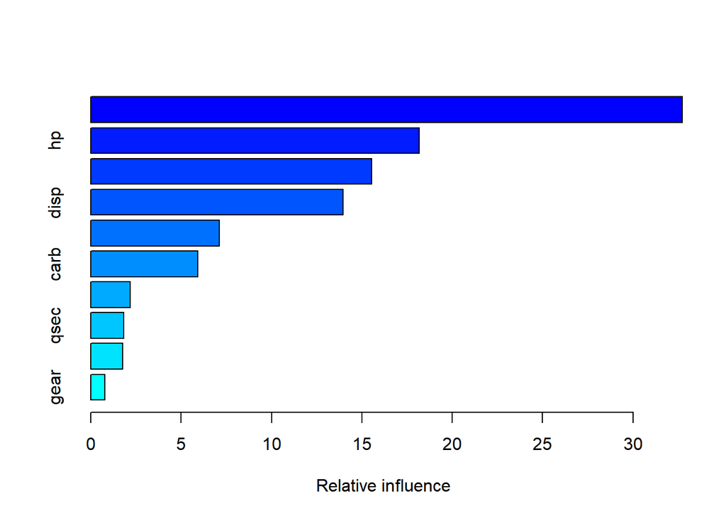

```
##       var    rel.inf
## cyl   cyl 32.7220996
## hp     hp 18.1639240
## wt     wt 15.5317608
## disp disp 13.9555252
## drat drat  7.1041961
## carb carb  5.9193511
## vs     vs  2.1939814
## qsec qsec  1.8398892
## am     am  1.7764129
## gear gear  0.7928598
```

```r
summary(mtcars.boost)
```

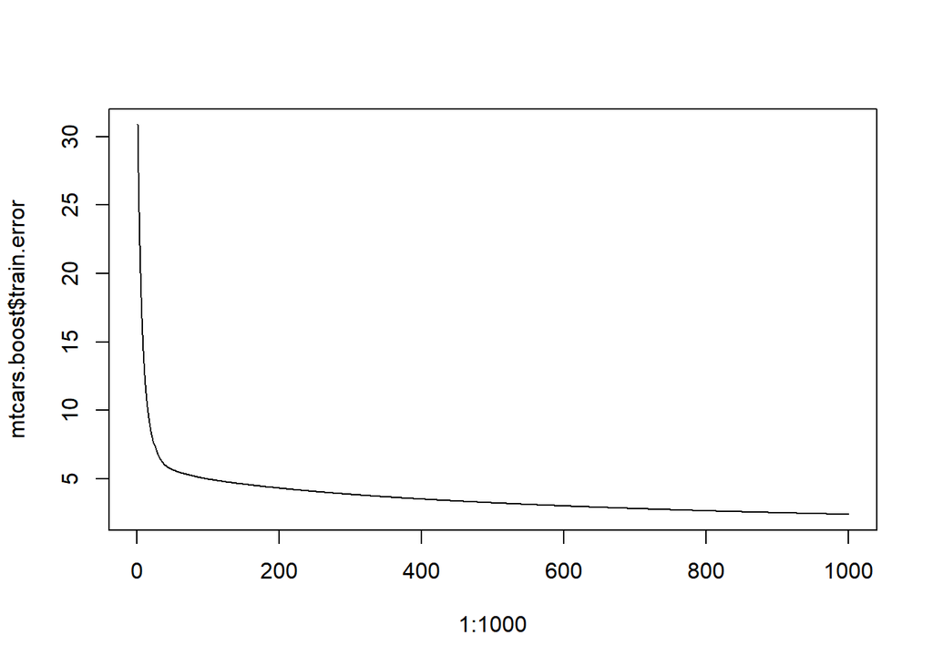

```r
plot(1:1000,mtcars.boost$train.error,type="l")
```

```r
mtcars.boost$train.error[c(1,100,1000)]
```

```
## [1] 30.889100  4.961320  2.380536
```

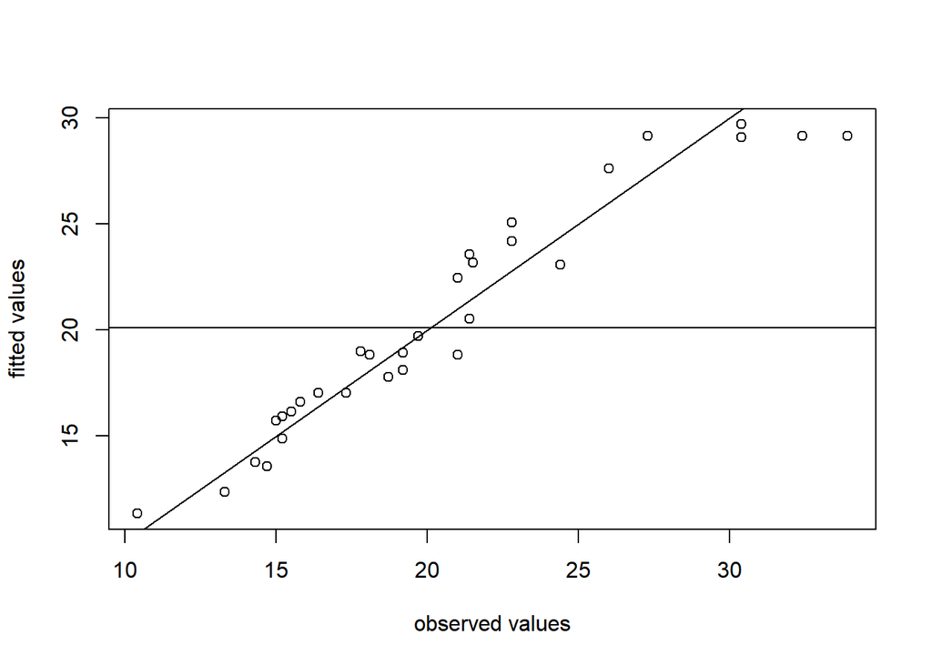

```r
plot(mtcars$mpg,predict(mtcars.boost,n.trees=1000),ylab="fitted values",xlab="observed values")
abline(h=mean(mtcars$mpg))
abline(c(0,1))
```

The calculated error converts against 0 as expected. The difference in the error between 1 and 100 trees is tremendous, but very low between 100 and 1000 trees. The fitted values are getting closer to the observed ones.

## Try another shrinkage rate

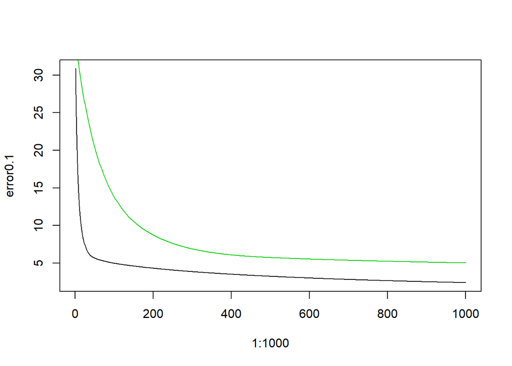

```r
error0.1<-mtcars.boost$train.error
mtcars.boost<-gbm(mpg ~ ., data=mtcars, n.trees=1000,distribution="gaussian",shrinkage=0.01,bag.fraction=1)
plot(1:1000,error0.1,type="l")
lines(1:1000,mtcars.boost$train.error,col=3)
```

Using a lower shrinkage rate results in a slower fitting model.

# SVM

The following code comes from the lab exercise 9.6.1 Support Vector Classifier in James et al.